## MBA 561 Final Project

title: “wfkelly2_project” author: “William Kelly” date: “5/7/2021” output: html_document —

# Load Libraries

```r
library(tidyr) # For lots of data wrangling tasks
library(magrittr) # For piping data into functions
library(lubridate) # For dealing with dates
library(stringr) # String functions
library(forcats) #fct infreq functions
library(dplyr) # Data manipulation
```

# Q1 Read in ities.csv and max_temp.csv into Dataframes

```r
df <- read.csv("ities.csv") # Read ities.csv into data frame
df_weather_weekly <- read.csv("max_temp.csv") # Read max_temp.csv into data frame
```

# Q2 Display Rows and Cols of df and df_weather_weekly

```r
dim(df) # Display Row/Col of df
```

```
## [1] 438151     13
```

```r
dim(df_weather_weekly) # Display Row/Col of df_weather_weekly
```

```
## [1] 52  9
```

# Q3 Display structures of df and df_weather_weekly

```r
str(df) # Display structure of df
```

```
## 'data.frame':    438151 obs. of  13 variables:
##  $ Date             : chr  "7/18/2016" "7/18/2016" "7/18/2016" "7/18/2016" ...
##  $ OperationType    : chr  "SALE" "SALE" "SALE" "SALE" ...
##  $ CashierName      : chr  "Wallace Kuiper" "Wallace Kuiper" "Wallace Kuiper" "Wallace Kuiper" ...
##  $ LineItem         : chr  "Salmon and Wheat Bran Salad" "Fountain Drink" "Beef and Squash Kabob" "Salmon and Wheat Bran Salad" ...
##  $ Department       : chr  "Entrees" "Beverage" "Kabobs" "Salad" ...
##  $ Category         : chr  "Salmon and Wheat Bran Salad" "Fountain" "Beef" "general" ...
##  $ RegisterName     : chr  "RT149" "RT149" "RT149" "RT149" ...
##  $ StoreNumber      : chr  "AZ23501305" "AZ23501289" "AZ23501367" "AZ23501633" ...
##  $ TransactionNumber: chr  "002XIIC146121" "002XIIC146121" "00PG9FL135736" "00Z3B4R37335" ...
##  $ CustomerCode     : chr  "CWM11331L8O" "CWM11331L8O" "CWM11331L8O" "CWM11331L8O" ...
##  $ Price            : num  66.22 2.88 12.02 18.43 18.43 ...
##  $ Quantity         : int  1 1 2 1 1 1 1 1 1 1 ...
##  $ TotalDue         : num  66.22 2.88 24.04 18.43 18.43 ...
```

```r
str(df_weather_weekly) # Display structure of df_weather_weekly
```

```
## 'data.frame':    52 obs. of  9 variables:
##  $ Week        : int  1 2 3 4 5 6 7 8 9 10 ...
##  $ Monday      : num  46.9 48.9 48 34 51.1 ...
##  $ Tuesday     : num  45 46 52 41 60.1 ...
##  $ Wednesday   : num  41 46 53.1 51.1 57.9 ...
##  $ Thursday    : num  45 46.9 55 46.9 51.1 ...
##  $ Friday      : num  59 51.1 50 55.9 41 ...
##  $ Saturday    : num  57 42.1 51.1 51.1 48 ...
##  $ Sunday      : num  57 48.9 50 36 52 ...
##  $ WeekStarting: chr  "1/3/2016" "1/10/2016" "1/17/2016" "1/24/2016" ...
```

Many of the Datatypes in df are character so it is difficult to do calculations unless you convert to factor type especially date. Also the price and total due are in decimal numeric format. In the df_weather_weekly data frame the WeekStarting is in character need to convert to factor in order to do calculations in freq.

# Q4 Display summaries of df and df_weather_weekly

```r
summary(df) # Display summary of df
```

```
##      Date           OperationType      CashierName          LineItem
##  Length:438151      Length:438151      Length:438151      Length:438151
##  Class :character   Class :character   Class :character   Class :character
##  Mode  :character   Mode  :character   Mode  :character   Mode  :character
##
##
##
##
##   Department          Category         RegisterName       StoreNumber
##  Length:438151      Length:438151      Length:438151      Length:438151
##  Class :character   Class :character   Class :character   Class :character
##  Mode  :character   Mode  :character   Mode  :character   Mode  :character
##
##
##
##
##  TransactionNumber  CustomerCode           Price             Quantity
##  Length:438151      Length:438151      Min.   :-5740.51   Min.   :  1.000
##  Class :character   Class :character   1st Qu.:    4.50   1st Qu.:  1.000
##  Mode  :character   Mode  :character   Median :   11.29   Median :  1.000
##                                        Mean   :   14.36   Mean   :  1.177
##                                        3rd Qu.:   14.68   3rd Qu.:  1.000
##                                        Max.   :21449.97   Max.   :815.000
##                                        NA's   :12
##     TotalDue
##  Min.   :-5740.51
##  1st Qu.:    4.50
##  Median :   11.80
##  Mean   :   15.26
##  3rd Qu.:   15.04
##  Max.   :21449.97
##  NA's   :12
```

```r
summary(df_weather_weekly) # Display summary of df_weather_weekly
```

```
##       Week           Monday          Tuesday         Wednesday
##  Min.   : 1.00   Min.   : 33.98   Min.   : 28.94   Min.   : 30.92
##  1st Qu.:13.75   1st Qu.: 48.92   1st Qu.: 50.00   1st Qu.: 51.98
##  Median :26.50   Median : 67.46   Median : 68.00   Median : 65.93
##  Mean   :26.50   Mean   : 68.29   Mean   : 68.12   Mean   : 69.19
##  3rd Qu.:39.25   3rd Qu.: 88.30   3rd Qu.: 87.58   3rd Qu.: 89.28
##  Max.   :52.00   Max.   :100.94   Max.   :100.94   Max.   :102.02
##     Thursday          Friday          Saturday          Sunday
##  Min.   : 30.92   Min.   : 33.08   Min.   : 28.94   Min.   : 33.98
##  1st Qu.: 50.54   1st Qu.: 55.45   1st Qu.: 53.96   1st Qu.: 51.98
##  Median : 67.01   Median : 65.03   Median : 68.54   Median : 70.52
##  Mean   : 69.41   Mean   : 70.68   Mean   : 70.58   Mean   : 69.25
##  3rd Qu.: 89.56   3rd Qu.: 91.27   3rd Qu.: 89.56   3rd Qu.: 89.96
##  Max.   :100.94   Max.   :104.00   Max.   :102.02   Max.   :102.92
##  WeekStarting
##  Length:52
##  Class :character
##  Mode  :character
##
##
##
```

# Q5 Display missing values in df

```r
colSums(is.na(df)) # Display columns with missing values
```

```
##              Date     OperationType       CashierName          LineItem
##                 0                 0                 0                 0
##        Department          Category      RegisterName       StoreNumber
##                 0                 0                 0                 0
## TransactionNumber      CustomerCode             Price          Quantity
##                 0                 0                12                 0
##          TotalDue
##                12
```

```r
# Calculate mean Price of Chicken and Onion Kabob (C_O) and Beef and Squash Kabob (B_S)
# Where Operation Type is Sale in order to fill in missing observations.
C_O_kabob_sale <- df %>%
  filter(LineItem=='Chicken and Onion Kabob' & OperationType=='SALE') %>%
  summarise(mean(Price, na.rm = T))

B_S_kabob_sale <- df %>%
  filter(LineItem=='Beef and Squash Kabob' & OperationType=='SALE') %>%
  summarise(mean(Price, na.rm = T))

# Replace Line Items with Average Price values calculated above and Calc Total Due
df %<>% mutate(
  Price = case_when(
    is.na(Price) & LineItem=='Chicken and Onion Kabob' ~ C_O_kabob_sale[1,1]
    , is.na(Price) & LineItem=='Beef and Squash Kabob' ~ B_S_kabob_sale[1,1]
    , T~Price
  ),
  TotalDue = Price*Quantity
)
summary(df)
```

```
##      Date           OperationType      CashierName          LineItem
##  Length:438151      Length:438151      Length:438151      Length:438151
##  Class :character   Class :character   Class :character   Class :character
##  Mode  :character   Mode  :character   Mode  :character   Mode  :character
##
##
##
##   Department          Category         RegisterName       StoreNumber
##  Length:438151      Length:438151      Length:438151      Length:438151
##  Class :character   Class :character   Class :character   Class :character
##  Mode  :character   Mode  :character   Mode  :character   Mode  :character
##
##
##
##  TransactionNumber  CustomerCode           Price             Quantity
##  Length:438151      Length:438151      Min.   :-5740.51   Min.   :  1.000
##  Class :character   Class :character   1st Qu.:    4.50   1st Qu.:  1.000
##  Mode  :character   Mode  :character   Median :   11.29   Median :  1.000
##                                        Mean   :   14.36   Mean   :  1.177
##                                        3rd Qu.:   14.68   3rd Qu.:  1.000
##                                        Max.   :21449.97   Max.   :815.000
##     TotalDue
##  Min.   :-5740.51
##  1st Qu.:    4.50
##  Median :   11.80
##  Mean   :   15.26
##  3rd Qu.:   15.04
##  Max.   :21449.97
```

Noticed NAs located at Line Item Chicken and Onion Kabob and Beef and Squash Kabob So Calculated the mean of those line items in Sale Operation Type Then used the case when to replace the NA Price and TotalDue Wanted to input in order to keep the records for each customer transaction.

# Q6 Create Dataset df_daily aggregate df at daily level w/ Quantity & TotalDue

```r
df_daily <- df %>%
  mutate(
    Date = mdy(Date)
    , Date = round_date(Date, 'day')
  ) %>%
  group_by(Date) %>%
  summarise(Quantity = sum(Quantity)
            , TotalDue = sum(TotalDue)) %>%
  ungroup()
```

Used the sum function for the columns Quantity and TotalDue in order to calculate the total of cols Quantity and Total Due for each day to figure out which day of the year has the most frequency of purchases and understand consumers preferences.

# Q7 Convert df_weather_weekly from wide to long

```r
df_weather_daily <- df_weather_weekly %>%
  pivot_longer(cols = Monday:Sunday
               , names_to = 'day'
               , values_to = 'max_temp')
```

# Q8 Merge/Join df_daily and df_weather_daily

```r
df_weather_daily %<>%     # Convert WeekStarting col to Date to create primary key
  mutate(Date = mdy(WeekStarting))

df_weather_daily$day <- as_factor(df_weather_daily$day) %>%
  as.numeric()

df_weather_daily$Date <- df_weather_daily$day + df_weather_daily$Date - 1

df_final <- df_daily %>%
  inner_join(df_weather_daily, by = 'Date') %>%
  arrange(desc(Date))
```

# Q9 Create Pair Plot for df_final

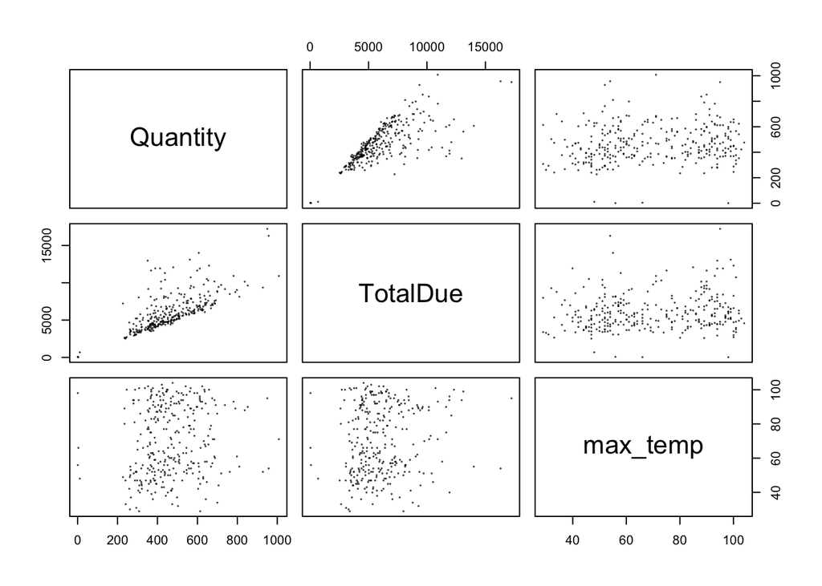

```r
#Pair Plot of Quantity, TotalDue, and max_temp from df_final
plot(df_final[,c('Quantity', 'TotalDue', 'max_temp')], cex = .1)
```

From the pair plots shown there is a positive relationship b/t ‘Quantity’ & ‘TotalDue’ signifying that as the quantity goes up the total due variable goes up as well. Also there are several outliers w/ Quantity vs TotalDue at 0 and 1000(Q) & 15000(TD). In addition, the relationship b/t max_temp & quantity and max_temp & TotalDue don’t have as much correlation it is spread throughout w/ max_temp ranging from 40 to 100.